# ENGS 93 HW 4

Cameron Wolfe 2/28/2024

```python
import numpy as np
import pandas as pd
import statsmodels.api as sm
from statsmodels.formula.api import ols
from scipy.stats import t, norm, chi2, f
from math import sqrt, exp, ceil, floor
import matplotlib.pyplot as plt

def normal_probability_plot(
    data_array: np.ndarray,
    title: str = "Normal Probability Plot",
) -> None:
    sorted_array = np.sort(data_array.flatten())

    n = len(sorted_array)

    z = np.zeros(n)

    for i in range(n):
        z[i] = norm.ppf((i + 0.5) / n)

    plt.scatter(sorted_array, z)
    plt.title(title)
    plt.xlabel("Values")
    plt.ylabel("Z value")
    plt.show()
```

## Problem 1

```python
sat_data = np.genfromtxt("sat.csv", delimiter=",")[1:, 1:]
```

### Part a

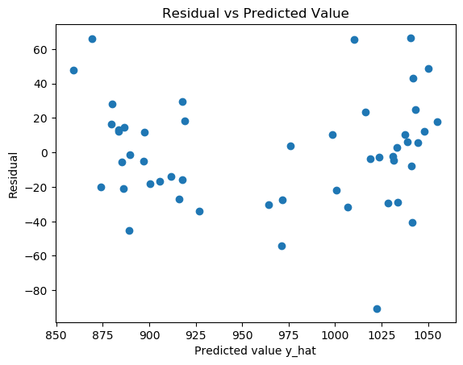

```python
x_data = sat_data[:, 0:4]
y = sat_data[:, 6]
num_data_points = len(y)
x = np.concatenate([np.ones((num_data_points, 1)), x_data], axis=1)
beta = np.linalg.solve(np.matmul(np.transpose(x), x), np.matmul(np.transpose(x), y))

y_hat = np.matmul(x, beta)
residual = y - y_hat

plt.scatter(y_hat, residual)
plt.title("Residual vs Predicted Value")
plt.xlabel("Predicted value y_hat")
plt.ylabel("Residual")
plt.show()
```

Variance appears to remain constant

### Part b

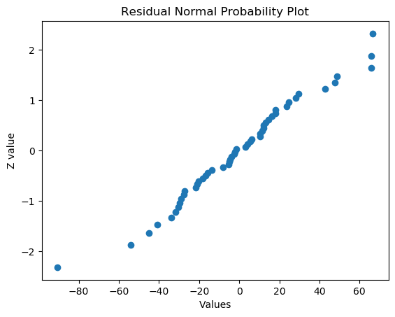

```python
normal_probability_plot(
    np.reshape(residual, (-1)),
    "Residual Normal Probability Plot"
)
```

Residuals appear to be normally distributed

### Part c

```
Outliers: (array([28, 33, 43, 47]),)
```

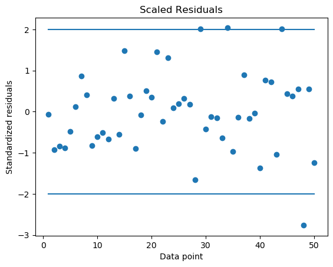

```python
MSE = np.sum(residual ** 2) / (num_data_points - 5)
scaled_residual = residual / sqrt(MSE)
outliers = np.where(np.logical_or(scaled_residual > 2, scaled_residual < -2))
print("Outliers:", outliers)
plt.scatter(np.array(list(range(1, 51))), scaled_residual)
plt.title("Scaled Residuals")
plt.xlabel("Data point")
plt.ylabel("Standardized residuals")
plt.plot([1, 50, np.nan, 50, 1], [-2, -2, np.nan, 2, 2])
plt.show()
```

As we can see that there are 4 outliers with scaled residuals outside the range [-2, 2]. The outlier states are: Nevada, North Carolina, Texas, and West Virginia.

## Problem 2

```python
beta = np.array([300, 0.85, 10.40])
SST = 1230.5
SSE = 120.3
alpha = 0.05
n = 15
k = 2
p = 3
```

### Part a

```python
SSR = SST - SSE
F_0 = SSR / k / (SSE / (n - p))
f_alpha = f.ppf(1-alpha, k, n - p)

print("Test Statistic:", F_0)
print("Critical Value:", f_alpha)
```

```
Test Statistic: 55.3715710723192
Critical Value: 3.8852938346523933
```

Can reject the null hypothesis as the test statistic is greater than the critical value. Therefore we can declare that the regression is significant.

### Part b

```python
R_squared = SSR / SST
adjusted_R_squared = 1 - SSE / (n - p) / (SST / (n - 1))
print("R^2 value:", R_squared)
print("Adjusted R^2 value:", adjusted_R_squared)
```

```
R^2 value: 0.902234863876473
Adjusted R^2 value: 0.8859406745225518
```

~90% of the variance in the data can be explained by the regression, depending on whether you use the standard or adjusted R^2 statistic.

### Part c

```python
mse = SSE / (n - p)
print("Old MSE:", mse)
new_SSE = 117.20
k = k + 1
p = p + 1
new_mse = new_SSE / (n - p)
print("New MSE:", new_mse)
```

```
Old MSE: 10.025
New MSE: 10.654545454545454
```

As can be seen, the MSE increased from the original regression, meaning that by adding the new parameter, we are overfitting. This can also be seen by looking at the adjusted R^2 value.

```python
R_squared = 1 - new_SSE / SST
adjusted_R_squared = 1 - new_SSE / (n - p) / (SST / (n - 1))
print("R^2 value:", R_squared)
print("Adjusted R^2 value:", adjusted_R_squared)
```

```
R^2 value: 0.904754164973588
Adjusted R^2 value: 0.8787780281482028
```

While the R^2 increases, the adjusted R^2 decreases, meaning that by adding the new parameter, we are overfitting the data.

### Part d

```python
SSR_b3_given_b2 = (SST - new_SSE) - (SST - SSE)
F_0 = SSR_b3_given_b2 / 1 / (new_SSE / (n - p))
f_alpha = f.ppf(1-alpha, 1, n - p)

print("Test statistic:", F_0)
print("Critical value:", f_alpha)
```

```
Test statistic: 0.29095563139930886
Critical value: 4.844335674943618
```

Cannot reject $H_0$ as the test statistic is less than the critical value. This means we can declare that the new variable addition is not significant.

## Problem 3

### Part a

```python
heat_cement_data = np.genfromtxt("heat_cement.csv", delimiter=",")[1:,:]
y = heat_cement_data[:, 0]
x_data = heat_cement_data[:, 1:]
n = len(y)
p = 3
x = np.concatenate([np.ones((n, 1)), x_data], axis=1)
beta = np.linalg.solve(np.matmul(np.transpose(x), x), np.matmul(np.transpose(x), y))
print("Regression parameters:", beta)
print("y_hat = " + str(beta[0]) + " + " + str(beta[1]) + " * x_1 + " + str(beta[2]) + " * x_2 + " + str(beta[3]) + " * x_3")
```

```
Regression parameters: [-39.91967442   0.7156402    1.29528612  -0.15212252]
y_hat = -39.91967442012454 + 0.7156402004852787 * x_1 + 1.2952861243885896 * x_2 + -0.15212251914864716 * x_3
```

### Part b

```python
residual = y - np.matmul(x, beta)
SST = np.sum(y ** 2) - n * y.mean()**2
SSE = np.sum(residual ** 2)

R_squared = 1 - SSE / SST
print("R^2:", R_squared)
```

```
R^2: 0.9135769044606818
```

### Part c

```python
new_x = x[:, [0, 2, 3]]
new_beta = np.linalg.solve(
    np.matmul(np.transpose(new_x), new_x),
    np.matmul(np.transpose(new_x), y)
)
r = 1
new_residual = y - np.matmul(new_x, new_beta)
SSE_reduced = np.sum(new_residual ** 2)
alpha = 0.05
F_0 = ((SSE_reduced - SSE) / r) / (SSE / (n - p - 1))
f_alpha = f.ppf(1-alpha, r, n - p - 1)

print("Test statistic:", F_0)
print("Critical value:", f_alpha)
```

```
Test statistic: 28.160141604334104
Critical value: 4.451321772468133
```

Can conclude that % of tricalcium aluminate is significant in explaining the heat evolved during the hardening of cement.

## Problem 4

### Part a

```python
airline_data = np.genfromtxt("airline.csv", delimiter=",")[1:, :]
y = airline_data[:, 0]
x_data = airline_data[:, 1:]
n = len(y)
p = 4
x = np.concatenate([np.ones((n, 1)), x_data], axis=1)
beta = np.linalg.solve(np.matmul(np.transpose(x), x), np.matmul(np.transpose(x), y))
print("Regression coefficients:", beta)
```

```
Regression coefficients: [  2.53732669   0.91930855 659.26822475   2.17963956]
```

### Part b

```python
residual = y - np.matmul(x, beta)
SSE = np.sum(residual ** 2)
SST = np.sum(y ** 2) - y.mean()** 2 * n
SSR = SST - SSE

F0 = (SSR / p) / (SSE / (n - p - 1))
p = f.sf(F0, p, n - p - 1)
print("P-value:", p)
```

```
P-value: 2.0815942472805593e-14
```

Because $p < \alpha = 0.01$, can reject $H_0$ and conclude that there is a significant relationship between the parameters and the data.

### Part c

```python
new_x = x[:, 0:2]
new_beta = np.linalg.solve(
    np.matmul(np.transpose(new_x), new_x),
    np.matmul(np.transpose(new_x), y)
)
new_residual = y - np.matmul(new_x, new_beta)
SSE_reduced = np.sum(new_residual ** 2)
r = 2
f_val = (SSE_reduced - SSE) / r / (SSE / (n - p - 1))
p = f.sf(f_val, r, n-p-1)
print("P-value:", p)
```

```
P-value: 3.844408181787328e-16
```

Because $p < \alpha = 0.01$, we can reject $H_0$ and conclude that $\beta_2$ and $\beta_3$ add significant prediction power to the regression

## Problem 5

```python
sample_means = np.array([5.43, 3.99, 4.86, 5.65, 4.80])
sample_variances = np.array([2.66, 3.08, 2.57, 3.38, 2.60])
I = 5
measurements = 40 * np.ones(I)
N = np.sum(measurements)
total_mean = np.sum(sample_means * measurements) / N
```

### Part a

```python
SST = (
    np.sum(sample_variances * (measurements - 1) + measurements * sample_means **2)
    - N * total_mean ** 2
)

SS_treatment = np.sum(measurements * sample_means ** 2) - N * total_mean**2
SSE = SST - SS_treatment

MSE = SSE / (N - I)
print("Within group variance:", MSE)
```

```
Within group variance: 2.8579999999999974
```

### Part b

```python
F_0 = (SS_treatment / (I - 1)) / (SSE / (N - I))
print("F-statistic:", F_0)
```

```
F-statistic: 5.85206438068575
```

### Part c

```python
p = f.sf(F_0, I - 1, N - I)
print("P-value:", p)
```

```
P-value: 0.00018131623842649586
```

Using $\alpha = 0.05$, we can conclude that there are two populations that are significantly different as $p < \alpha$

## Problem 6

```python
fatigue_crack_data = np.array([[2.29, 2.06, 1.90],
[2.47, 2.05, 1.93],
[2.48, 2.23, 1.75],
[2.12, 2.03, 2.06],
[2.65, 3.20, 3.10],
[2.68, 3.18, 3.24],
[2.06, 3.96, 3.98],
[2.38, 3.64, 3.24],
[2.24, 11.00, 9.96],
[2.71, 11.00, 10.01],
[2.81, 9.06, 9.36],
[2.08, 11.3, 10.40]])
I, J, K = 3, 3, 4

fatigue_crack_data = np.transpose(np.reshape(np.transpose(fatigue_crack_data), (I, J, K)), (1, 0, 2))
```

### Part a

```python
num_factors = 2
levels_A = fatigue_crack_data.shape[0]
levels_B = fatigue_crack_data.shape[1]
replicates = fatigue_crack_data.shape[2]

df = pd.DataFrame({
    'value': fatigue_crack_data.flatten(),
    'Frequency': np.repeat(np.arange(levels_A), levels_B*replicates),
    'Environment': np.tile(np.repeat(np.arange(levels_B), replicates), levels_A)
})

model = ols('value ~ C(Frequency) + C(Environment) + C(Frequency):C(Environment)', data=df).fit()
anova_table = sm.stats.anova_lm(model, typ=2)

print(anova_table)
```

```
                                 sum_sq    df           F        PR(>F)
C(Frequency)                 209.892822   2.0  522.398193  2.611529e-22
C(Environment)                64.252156   2.0  159.915950  1.075979e-15
C(Frequency):C(Environment)  101.965794   4.0  126.890349  4.324070e-17
Residual                       5.424125  27.0         NaN           NaN
```

From this, we can reject the additive model, meaning that it is the combination of factors that causes changes in crack growth rate, and not just frequency or environment.

### Part b

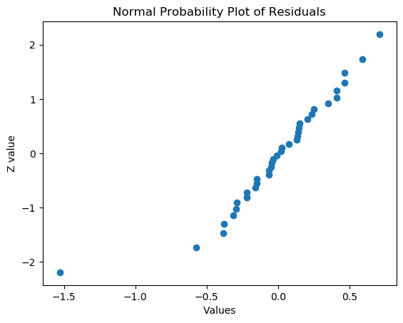

```python
treatment_means = np.mean(fatigue_crack_data, 2)
row_means = np.mean(treatment_means, 1)
column_means = np.mean(treatment_means, 0)
grand_mean = np.mean(row_means)

row_effects = row_means - grand_mean
column_effects = column_means - grand_mean
interaction_effects = np.zeros((3,3))
for i in range(I):
    for j in range(J):
        interaction_effects[i, j] = (
            treatment_means[i, j]
            - row_means[i]
            - column_means[j]
            + grand_mean
            )

error = np.zeros(fatigue_crack_data.shape)
for i in range(I):
    for j in range(J):
        for k in range(K):
            error[i,j,k] = fatigue_crack_data[i,j,k] - treatment_means[i,j]
normal_probability_plot(error.reshape((-1)), "Normal Probability Plot of Residuals")
```

Residuals appear to be normally distributed, with one outlier.

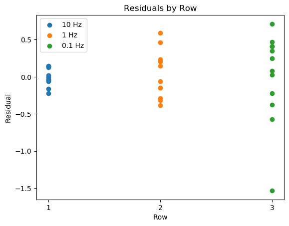

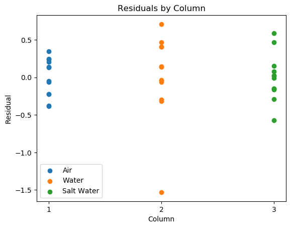

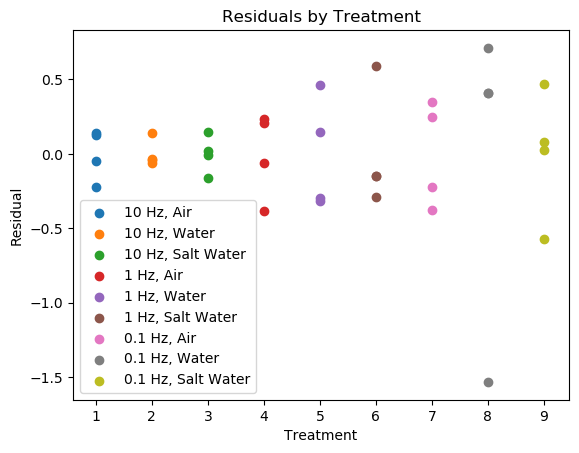

```python
frequency_values = ["10 Hz", "1 Hz", "0.1 Hz"]
environment_types = ["Air", "Water", "Salt Water"]
residuals_by_row = []
residuals_by_column = []
residuals_by_treatment = []
for i in range(I):
    residuals_by_row.append(error[i, :, :].reshape((-1)))
    label_x = np.full((J*K), str(i+1), dtype=str)
    plt.scatter(label_x, residuals_by_row[i], label=frequency_values[i])
plt.title("Residuals by Row")
plt.xlabel("Row")
plt.ylabel("Residual")
plt.legend(loc="best")
plt.show()

for j in range(J):
    residuals_by_column.append(error[:, j, :].reshape((-1)))
    label_x = np.full((I*K), str(j+1), dtype=str)
    plt.scatter(label_x, residuals_by_column[j], label=environment_types[j])
plt.title("Residuals by Column")
plt.xlabel("Column")
plt.ylabel("Residual")
plt.legend(loc="best")
plt.show()

for i in range(I):
    for j in range(J):
        residuals_by_treatment.append(error[i,j,:].reshape((-1)))
        label_x = np.full((K), str(3 * i + j + 1), dtype=str)
        plt.scatter(label_x, residuals_by_treatment[-1], label=(frequency_values[i] + ", " + environment_types[j]))
plt.title("Residuals by Treatment")
plt.xlabel("Treatment")
plt.ylabel("Residual")
plt.legend(loc="best")
plt.show()
```

### Part c

```python
fatigue_crack_data = np.log(fatigue_crack_data)
df = pd.DataFrame({
    'value': fatigue_crack_data.flatten(),
    'Frequency': np.repeat(np.arange(levels_A), levels_B*replicates),
    'Environment': np.tile(np.repeat(np.arange(levels_B), replicates), levels_A)
})

model = ols('value ~ C(Frequency) + C(Environment) + C(Frequency):C(Environment)', data=df).fit()
anova_table = sm.stats.anova_lm(model, typ=2)

print(anova_table)

treatment_means = np.mean(fatigue_crack_data, 2)
row_means = np.mean(treatment_means, 1)
column_means = np.mean(treatment_means, 0)
grand_mean = np.mean(row_means)

row_effects = row_means - grand_mean
column_effects = column_means - grand_mean
interaction_effects = np.zeros((3,3))
for i in range(I):
    for j in range(J):
        interaction_effects[i, j] = treatment_means[i, j] - row_means[i] - column_means[j] + grand_mean

error = np.zeros(fatigue_crack_data.shape)
for i in range(I):
    for j in range(J):
        for k in range(K):
            error[i,j,k] = fatigue_crack_data[i,j,k] - treatment_means[i,j]
```

```
                               sum_sq    df           F        PR(>F)
C(Frequency)                 7.570235   2.0  404.094970  7.573731e-21
C(Environment)               2.357628   2.0  125.848875  2.061148e-14
C(Frequency):C(Environment)  3.528400   4.0   94.172027  1.884673e-15
Residual                     0.252906  27.0         NaN           NaN
```

From this, we can again conclude that there is a significant interaction component as $p < 0.05$.

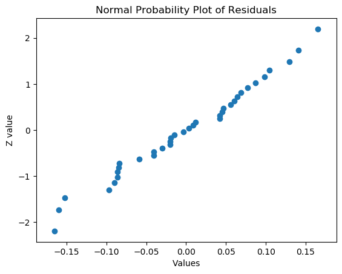

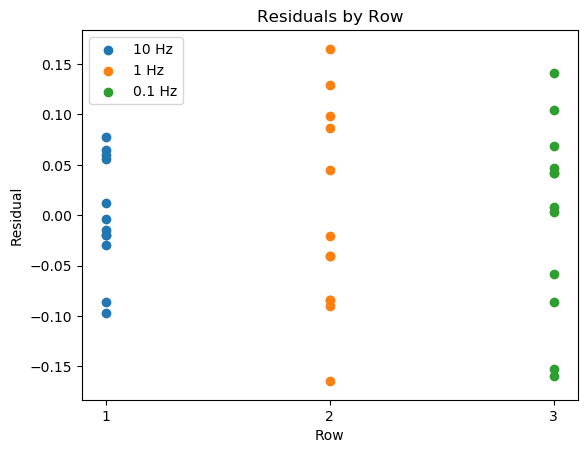

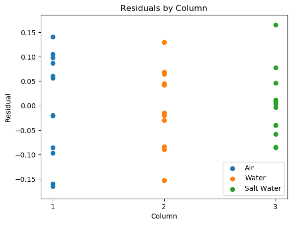

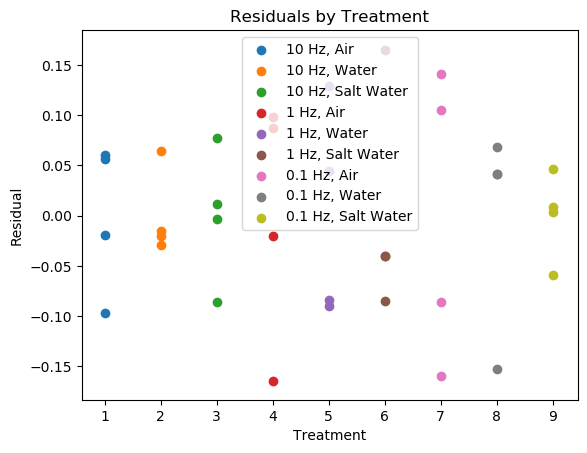

```python
normal_probability_plot(error.reshape((-1)), "Normal Probability Plot of Residuals")
frequency_values = ["10 Hz", "1 Hz", "0.1 Hz"]
environment_types = ["Air", "Water", "Salt Water"]
residuals_by_row = []
residuals_by_column = []
residuals_by_treatment = []
for i in range(I):
    residuals_by_row.append(error[i, :, :].reshape((-1)))
    label_x = np.full((J*K), str(i+1), dtype=str)
    plt.scatter(label_x, residuals_by_row[i], label=frequency_values[i])
plt.title("Residuals by Row")
plt.xlabel("Row")
plt.ylabel("Residual")
plt.legend(loc="best")
plt.show()

for j in range(J):
    residuals_by_column.append(error[:, j, :].reshape((-1)))
    label_x = np.full((I*K), str(j+1), dtype=str)
    plt.scatter(label_x, residuals_by_column[j], label=environment_types[j])
plt.title("Residuals by Column")
plt.xlabel("Column")
plt.ylabel("Residual")
plt.legend(loc="best")
plt.show()

for i in range(I):
    for j in range(J):
        residuals_by_treatment.append(error[i,j,:].reshape((-1)))
        label_x = np.full((K), str(3 * i + j + 1), dtype=str)
        plt.scatter(
            label_x, residuals_by_treatment[-1],
            label=(frequency_values[i] + ", " + environment_types[j])
        )
plt.title("Residuals by Treatment")
plt.xlabel("Treatment")
plt.ylabel("Residual")
plt.legend(loc="best")
plt.show()
```

Taking the natural log of the data appears to make the residuals more normal in their distribution

## Problem 7

### Part a

Because $p_\gamma > 0.05$, we cannot conclude that there is interaction between the catalyst and reagent. This means that the model is additive.

Reject that row effects (the catalyst used) are zero as $p_\alpha < 0.05$. This means that catalyst used has a signifcant impact on yield. Reject that column effects (the reagent used) are zero as $p_\beta < 0.05$. This means that reagent used has a signifcant impact on yield.

### Part b

```python
SSA = 50
SSB = 100
SSAB = 2
SSE = 400
I, J, K = 2, 4, 8
N = I * J * K
SST = SSA + SSB + SSAB + SSE

population_variance = SST / (N - 1)
print("Population variance:", population_variance)
```

```
Population variance: 8.761904761904763
```

### Part c

Since column factor is irrelevant, this means that SSE is comprised of the original SSE, SSB, and SSAB

```python
new_SSE = SSE + SSB + SSAB
new_MSE = new_SSE / (N - I)
F = (SSA / (I - 1)) / (new_MSE)

print(new_SSE, new_MSE)
p = f.sf(F, I - 1, N - I)
print("P-value:", p)
```

```
502 8.096774193548388
P-value: 0.01566702009762702
```

## Problem 8

```python
copper_data = np.genfromtxt("copper_content.csv", delimiter=",")[1:,1:]
n = 3
num_measurements = len(copper_data[:,0])
```

### Part a

From appendix XI, we have

```python
A2 = 1.023
d2 = 1.693
D3 = 0
D4 = 2.575
```

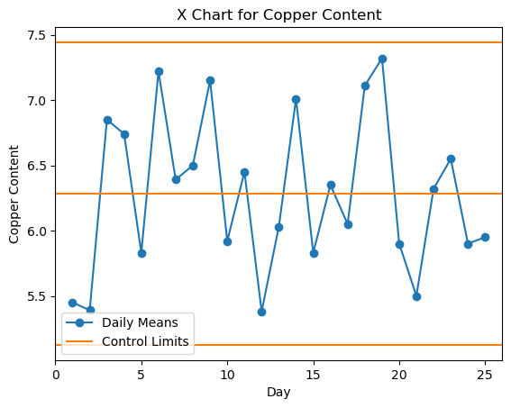

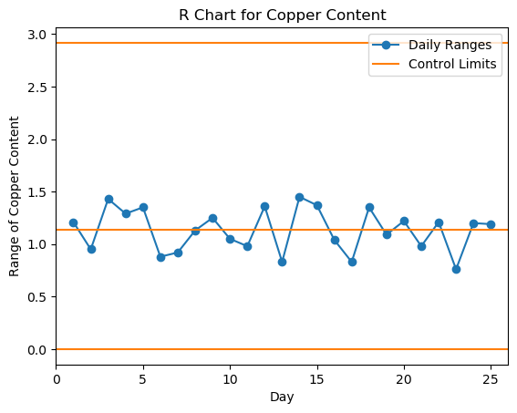

```python
x_bar_bar = copper_data[:, 0].mean()
r_bar = copper_data[:, 1].mean()
x_bar_lcl = x_bar_bar - A2 * r_bar
x_bar_ucl = x_bar_bar + A2 * r_bar
r_lcl = D3 * r_bar
r_ucl = D4 * r_bar

plt.plot(
    np.array(list(range(1, num_measurements + 1))),
    copper_data[:,0],
    marker='o',
    label="Daily Means"
)
plt.plot(
    np.array([
        0,
        num_measurements+1,
        np.nan,
        0,
        num_measurements+1,
        np.nan,
        0,
        num_measurements+1
    ]),
    np.array([
        x_bar_bar,
        x_bar_bar,
        np.nan,
        x_bar_lcl,
        x_bar_lcl,
        np.nan,
        x_bar_ucl,
        x_bar_ucl
    ]),
    label="Control Limits"
)
plt.xlim([0, num_measurements+1])
plt.title("X Chart for Copper Content")
plt.xlabel("Day")
plt.ylabel("Copper Content")
plt.legend(loc="best")
plt.show()

plt.plot(np.array(list(range(1, num_measurements + 1))), copper_data[:,1], marker='o', label="Daily Ranges")
plt.plot(
    np.array([
        0,
        num_measurements+1,
        np.nan,
        0,
        num_measurements+1,
        np.nan,
        0,
        num_measurements+1
    ]),
    np.array([r_bar, r_bar, np.nan, r_lcl, r_lcl, np.nan, r_ucl, r_ucl]),
    label="Control Limits"
)
plt.xlim([0, num_measurements+1])
plt.title("R Chart for Copper Content")
plt.xlabel("Day")
plt.ylabel("Range of Copper Content")
plt.legend(loc="best")
plt.show()
```

From what the charts show, we can conclude that the process is in statistical control.

### Part b

No changes needed to be made

### Part c

```python
estimated_std = r_bar / d2
print("Estimated standard deviation:", estimated_std)
```

```
Estimated standard deviation: 0.669108092144123
```